# Project1: Data Analysis of Life Expectancy (WHO)

Chunjingwen Cui and MING HAO LEE

2023-03-06

## Data Set: Life Expectancy (WHO)

We’ll be analyzing a dataset with information about many factors affecting life expectancy collected by World Health Organization (WHO). The data comes from this website: https://www.kaggle.com/datasets/kumarajarshi/life-expectancy-who?resource=download

The motivation of us to use this data set is that it has a large amount of data, including 22 columns and 2938 rows, which meets the requirements of this project. In addition, many factors affect life expectancy, and this dataset lists immune-related, mortality, economic, and social factors for 193 countries. By analyzing these data, we can understand how these factors affect human life expectancy. We can also make recommendations to the government to improve the population’s life expectancy based on the data analysis results.

In this data set, each observation represent some data related to life expectancy of a country in a particular year. Each variable presents as follow :

Country: 193 countries

Year: 2000-2015

Status: Developed or Developing status

Life expectancy: Life Expectancy in age

Adult Mortality: Adult Mortality Rates of both sexes (probability of dying between 15 and 60 years per 1000 population)

infant deaths: Number of Infant Deaths per 1000 population

Alcohol: Alcohol, recorded per capita (15+) consumption (in litres of pure alcohol)

percentage expenditure: Expenditure on health as a percentage of Gross Domestic Product per capita(%)

Hepatitis B: Hepatitis B (HepB) immunization coverage among 1-year-old (%)

Measles: Measles - number of reported cases per 1000 population

BMI: Average Body Mass Index of entire population

under-five deaths: Number of under-five deaths per 1000 population

Polio: Polio (Pol3) immunization coverage among 1-year-old (%)

Total expenditure: General government expenditure on health as a percentage of total government expenditure (%)

Diphtheria: Diphtheria tetanus toxoid and pertussis (DTP3) immunization coverage among 1-year-old (%)

HIV/AIDS: Deaths per 1 000 live births HIV/AIDS (0-4 years)

GDP: Gross Domestic Product per capital (in USD)

Population: Population of the country

thinness 1-19 years: Prevalence of thinness among children and adolescents for Age 10 to 19 (%)

thinness 5-9 years: Prevalence of thinness among children for Age 5 to 9(%)

Income composition of resources: Human Development Index in terms of income composition of resources (index ranging from 0 to 1)

Schooling: Number of years of Schooling(years)

## Start Anlysis

We’ll start by reading in the data:

```r
library(tidyverse)
setwd("~/Desktop")
lifeExpectancy<- read_csv("Life Expectancy Data.csv")
```

## Exploratory data analysis

### Descriptive statistics

Let’s start by finding some summaries of our variables to see which variables we have access to.

```r
str(lifeExpectancy)
```

```
## spc_tbl_ [2,938 × 22] (S3: spec_tbl_df/tbl_df/tbl/data.frame)
##  $ Country                        : chr [1:2938] "Afghanistan" "Afghanistan" "Afghanistan" "Afghanistan" ...
##  $ Year                           : num [1:2938] 2015 2014 2013 2012 2011 ...
##  $ Status                         : chr [1:2938] "Developing" "Developing" "Developing" "Developing" ...
##  $ Life expectancy                : num [1:2938] 65 59.9 59.9 59.5 59.2 58.8 58.6 58.1 57.5 57.3 ...
##  $ Adult Mortality                : num [1:2938] 263 271 268 272 275 279 281 287 295 295 ...
##  $ infant deaths                  : num [1:2938] 62 64 66 69 71 74 77 80 82 84 ...
##  $ Alcohol                        : num [1:2938] 0.01 0.01 0.01 0.01 0.01 0.01 0.01 0.03 0.02 0.03 ...
##  $ percentage expenditure         : num [1:2938] 71.3 73.5 73.2 78.2 7.1 ...
##  $ Hepatitis B                    : num [1:2938] 65 62 64 67 68 66 63 64 63 64 ...
##  $ Measles                        : num [1:2938] 1154 492 430 2787 3013 ...
##  $ BMI                            : num [1:2938] 19.1 18.6 18.1 17.6 17.2 16.7 16.2 15.7 15.2 14.7 ...
##  $ under-five deaths              : num [1:2938] 83 86 89 93 97 102 106 110 113 116 ...
##  $ Polio                          : num [1:2938] 6 58 62 67 68 66 63 64 63 58 ...
##  $ Total expenditure              : num [1:2938] 8.16 8.18 8.13 8.52 7.87 9.2 9.42 8.33 6.73 7.43 ...
##  $ Diphtheria                     : num [1:2938] 65 62 64 67 68 66 63 64 63 58 ...
##  $ HIV/AIDS                       : num [1:2938] 0.1 0.1 0.1 0.1 0.1 0.1 0.1 0.1 0.1 0.1 ...
##  $ GDP                            : num [1:2938] 584.3 612.7 631.7 670 63.5 ...
##  $ Population                     : num [1:2938] 33736494 327582 31731688 3696958 2978599 ...
##  $ thinness  1-19 years           : num [1:2938] 17.2 17.5 17.7 17.9 18.2 18.4 18.6 18.8 19 19.2 ...
##  $ thinness 5-9 years             : num [1:2938] 17.3 17.5 17.7 18 18.2 18.4 18.7 18.9 19.1 19.3 ...
##  $ Income composition of resources: num [1:2938] 0.479 0.476 0.47 0.463 0.454 0.448 0.434 0.433 0.415 0.405 ...
##  $ Schooling                      : num [1:2938] 10.1 10 9.9 9.8 9.5 9.2 8.9 8.7 8.4 8.1 ...
##  - attr(*, "spec")=
##   .. cols(
##   ..   Country = col_character(),
##   ..   Year = col_double(),
##   ..   Status = col_character(),
##   ..   `Life expectancy` = col_double(),
##   ..   `Adult Mortality` = col_double(),
##   ..   `infant deaths` = col_double(),
##   ..   Alcohol = col_double(),
##   ..   `percentage expenditure` = col_double(),
##   ..   `Hepatitis B` = col_double(),
##   ..   Measles = col_double(),
##   ..   BMI = col_double(),
##   ..   `under-five deaths` = col_double(),
##   ..   Polio = col_double(),
##   ..   `Total expenditure` = col_double(),
##   ..   Diphtheria = col_double(),
##   ..   `HIV/AIDS` = col_double(),
##   ..   GDP = col_double(),
##   ..   Population = col_double(),
##   ..   `thinness  1-19 years` = col_double(),
##   ..   `thinness 5-9 years` = col_double(),
##   ..   `Income composition of resources` = col_double(),
##   ..   Schooling = col_double()
##   .. )
##  - attr(*, "problems")=<externalptr>
```

```r
summary(lifeExpectancy)
```

```
##    Country               Year         Status          Life expectancy
##  Length:2938        Min.   :2000   Length:2938        Min.   :36.30
##  Class :character   1st Qu.:2004   Class :character   1st Qu.:63.10
##  Mode  :character   Median :2008   Mode  :character   Median :72.10
##                     Mean   :2008                      Mean   :69.22
##                     3rd Qu.:2012                      3rd Qu.:75.70
##                     Max.   :2015                      Max.   :89.00
##                                                       NA's   :10
##  Adult Mortality infant deaths       Alcohol        percentage expenditure
##  Min.   :  1.0   Min.   :   0.0   Min.   : 0.0100   Min.   :    0.000
##  1st Qu.: 74.0   1st Qu.:   0.0   1st Qu.: 0.8775   1st Qu.:    4.685
##  Median :144.0   Median :   3.0   Median : 3.7550   Median :   64.913
##  Mean   :164.8   Mean   :  30.3   Mean   : 4.6029   Mean   :  738.251
##  3rd Qu.:228.0   3rd Qu.:  22.0   3rd Qu.: 7.7025   3rd Qu.:  441.534
##  Max.   :723.0   Max.   :1800.0   Max.   :17.8700   Max.   :19479.912
##  NA's   :10                       NA's   :194
##   Hepatitis B       Measles              BMI        under-five deaths
##  Min.   : 1.00   Min.   :     0.0   Min.   : 1.00   Min.   :   0.00
##  1st Qu.:77.00   1st Qu.:     0.0   1st Qu.:19.30   1st Qu.:   0.00
##  Median :92.00   Median :    17.0   Median :43.50   Median :   4.00
##  Mean   :80.94   Mean   :  2419.6   Mean   :38.32   Mean   :  42.04
##  3rd Qu.:97.00   3rd Qu.:   360.2   3rd Qu.:56.20   3rd Qu.:  28.00
##  Max.   :99.00   Max.   :212183.0   Max.   :87.30   Max.   :2500.00
##  NA's   :553                        NA's   :34
##      Polio       Total expenditure   Diphtheria       HIV/AIDS
##  Min.   : 3.00   Min.   : 0.370    Min.   : 2.00   Min.   : 0.100
##  1st Qu.:78.00   1st Qu.: 4.260    1st Qu.:78.00   1st Qu.: 0.100
##  Median :93.00   Median : 5.755    Median :93.00   Median : 0.100
##  Mean   :82.55   Mean   : 5.938    Mean   :82.32   Mean   : 1.742
##  3rd Qu.:97.00   3rd Qu.: 7.492    3rd Qu.:97.00   3rd Qu.: 0.800
##  Max.   :99.00   Max.   :17.600    Max.   :99.00   Max.   :50.600
##  NA's   :19      NA's   :226       NA's   :19
##       GDP              Population        thinness  1-19 years
##  Min.   :     1.68   Min.   :3.400e+01   Min.   : 0.10
##  1st Qu.:   463.94   1st Qu.:1.958e+05   1st Qu.: 1.60
##  Median :  1766.95   Median :1.387e+06   Median : 3.30
##  Mean   :  7483.16   Mean   :1.275e+07   Mean   : 4.84
##  3rd Qu.:  5910.81   3rd Qu.:7.420e+06   3rd Qu.: 7.20
##  Max.   :119172.74   Max.   :1.294e+09   Max.   :27.70
##  NA's   :448         NA's   :652         NA's   :34
##  thinness 5-9 years Income composition of resources   Schooling
##  Min.   : 0.10      Min.   :0.0000                  Min.   : 0.00
##  1st Qu.: 1.50      1st Qu.:0.4930                  1st Qu.:10.10
##  Median : 3.30      Median :0.6770                  Median :12.30
##  Mean   : 4.87      Mean   :0.6276                  Mean   :11.99
##  3rd Qu.: 7.20      3rd Qu.:0.7790                  3rd Qu.:14.30
##  Max.   :28.60      Max.   :0.9480                  Max.   :20.70
##  NA's   :34         NA's   :167                     NA's   :163
```

```r
head(lifeExpectancy)
```

```
## # A tibble: 6 × 22
##   Country    Year Status Life …¹ Adult…² infan…³ Alcohol perce…⁴ Hepat…⁵ Measles
##   <chr>     <dbl> <chr>    <dbl>   <dbl>   <dbl>   <dbl>   <dbl>   <dbl>   <dbl>
## 1 Afghanis…  2015 Devel…    65       263      62    0.01   71.3       65    1154
## 2 Afghanis…  2014 Devel…    59.9     271      64    0.01   73.5       62     492
## 3 Afghanis…  2013 Devel…    59.9     268      66    0.01   73.2       64     430
## 4 Afghanis…  2012 Devel…    59.5     272      69    0.01   78.2       67    2787
## 5 Afghanis…  2011 Devel…    59.2     275      71    0.01    7.10      68    3013
## 6 Afghanis…  2010 Devel…    58.8     279      74    0.01   79.7       66    1989
## # … with 12 more variables: BMI <dbl>, `under-five deaths` <dbl>, Polio <dbl>,
## #   `Total expenditure` <dbl>, Diphtheria <dbl>, `HIV/AIDS` <dbl>, GDP <dbl>,
## #   Population <dbl>, `thinness  1-19 years` <dbl>, `thinness 5-9 years` <dbl>,
## #   `Income composition of resources` <dbl>, Schooling <dbl>, and abbreviated
## #   variable names ¹`Life expectancy`, ²`Adult Mortality`, ³`infant deaths`,
## #   ⁴`percentage expenditure`, ⁵`Hepatitis B`
```

Based on this output, we have an interesting phenomenon that the Min of some variables are 0 which maybe because the data lost.

Let’s try to see how many different developing and developed countries within this dataset

```r
lifeExpectancy %>%
  group_by(Status) %>%
  summarize(count = n()) %>%
  arrange(desc(count))
```

```
## # A tibble: 2 × 2
##   Status     count
##   <chr>      <int>
## 1 Developing  2426
## 2 Developed    512
```

Let’s then see which countries has the Longest life expectancy!

```r
lifeExpectancy %>%
  group_by(Country) %>%
  summarize(avg_LE = mean(`Life expectancy`)) %>%
  arrange(desc(avg_LE))
```

```
## # A tibble: 193 × 2
##    Country     avg_LE
##    <chr>        <dbl>
##  1 Japan         82.5
##  2 Sweden        82.5
##  3 Iceland       82.4
##  4 Switzerland   82.3
##  5 France        82.2
##  6 Italy         82.2
##  7 Spain         82.1
##  8 Australia     81.8
##  9 Norway        81.8
## 10 Canada        81.7
## # … with 183 more rows
```

Japan is win! About 82.53 is the highest life expectancy.

Then let’s look at which countries has the most high average of alcohol consumption.

```r
lifeExpectancy %>%
  group_by(Country) %>%
  summarize(avg_Al = mean(Alcohol)) %>%
  arrange(desc(avg_Al))
```

```
## # A tibble: 193 × 2
##    Country                                               avg_Al
##    <chr>                                                  <dbl>
##  1 United Kingdom of Great Britain and Northern Ireland 11.1
##  2 New Zealand                                           9.17
##  3 Saint Kitts and Nevis                                 8.54
##  4 Norway                                                6.23
##  5 Albania                                               4.85
##  6 Singapore                                             1.76
##  7 Afghanistan                                           0.0144
##  8 Cook Islands                                          0.01
##  9 Dominica                                              0.01
## 10 Marshall Islands                                      0.01
## # … with 183 more rows
```

Base on the result, United Kingdom of Great Britain and Northern Ireland is the winner which data is around 11.13.

Finally, let’s take a look at the difference average schooling between developed countries and developing countries.

```r
lifeExpectancy %>%
  group_by(Status) %>%
  drop_na(Schooling)%>%
  summarize(avg_Sc = mean(Schooling)) %>%
  arrange(desc(avg_Sc))
```

```
## # A tibble: 2 × 2
##   Status     avg_Sc
##   <chr>       <dbl>
## 1 Developed    15.8
## 2 Developing   11.2
```

Base on the result, the developed is 15.8 which is more then 11.2 of developing countries.

### Exploratory visualizations

Now let’s find some visualizations of our data.

Let’s look at the relationships between our quantitative variables:

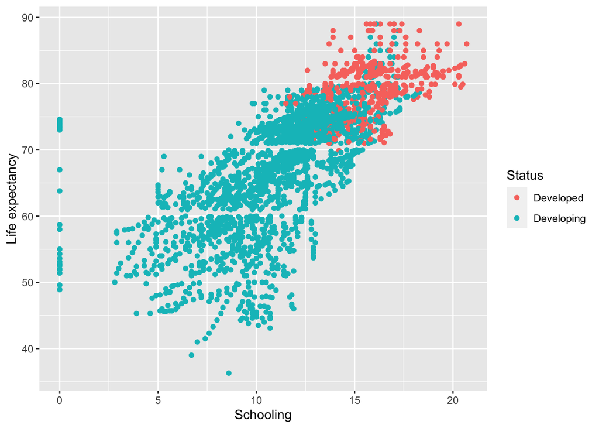

```r
lifeExpectancy %>%
  ggplot(aes(Schooling, `Life expectancy`,
             color = Status)) +
  geom_point()
```

Based on the output, we could find out that longer schooling, longer life expectation on both Developed or Developing countries. And the developed countries seem like havig longer life expectancy and longer schooling years.

Whereas there do have some outliers of schooling.

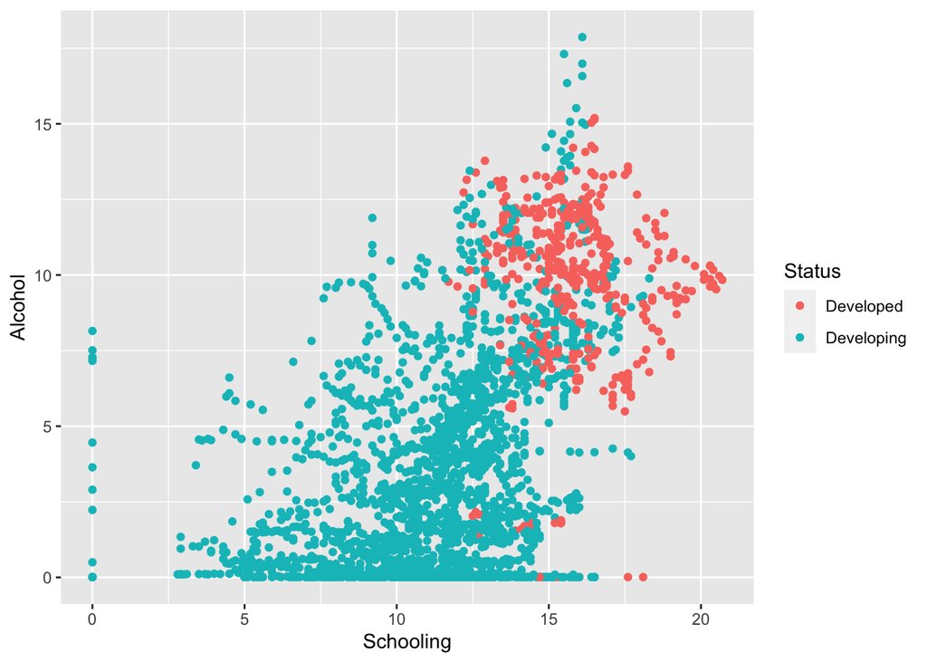

```r
lifeExpectancy %>%
  ggplot(aes(Schooling, Alcohol,
             color = Status)) +
  geom_point()
```

This is a scatterplot of Schooling and Alcohol. The result is very interesting. From this chart, we can see that the countries which have longer schooling time may consume more alcohol. Besides, developed countries consume more alcohol than developing countries.

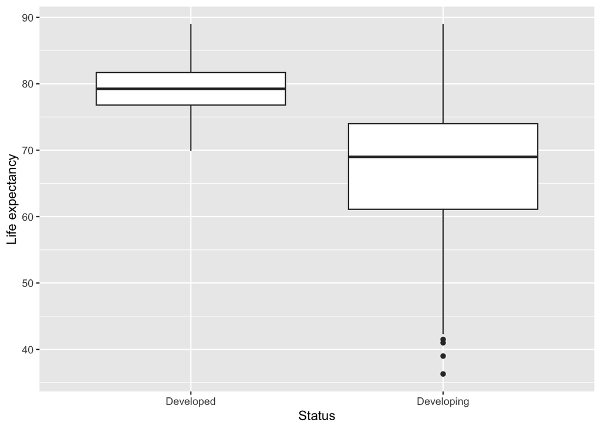

```r
lifeExpectancy %>%
  ggplot(aes(Status, `Life expectancy`)) +
  geom_boxplot()
```

This boxplot shows the distributions of developed and developing countries. From this result, we may conclude that developed countries have longer life expectancy than developing countries.

## Statistic analysis

Now, we can do some statistic analysis on this data, such as correlation analysis, linear regression and t-test.

### Correlation

Firstly, we try to find the relationships between the three quantitative variables that we focusing on - life expectancy, schooling, and alcohol.

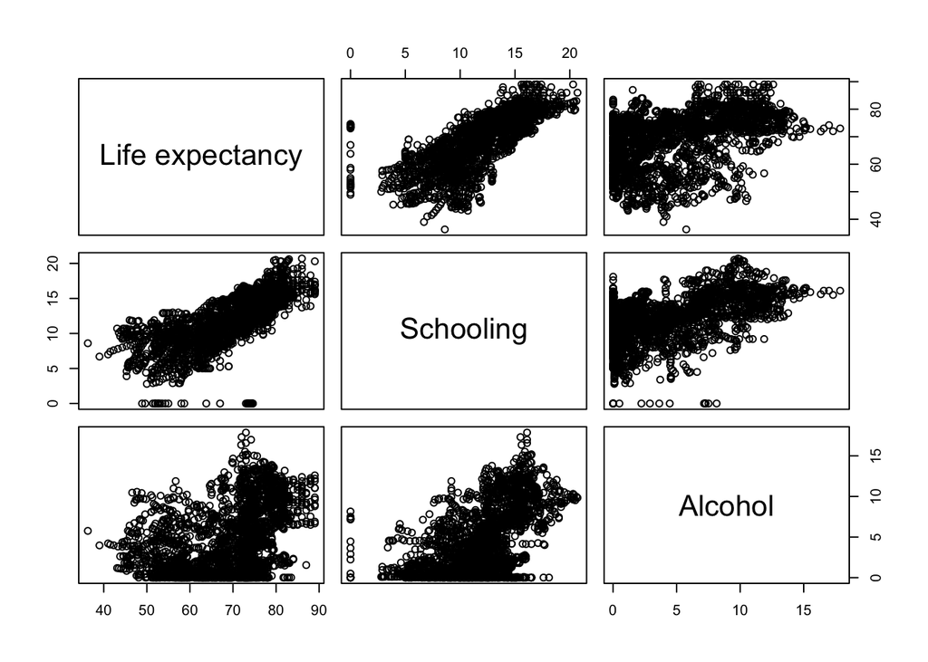

```r
lifeExpectancy %>%
  select(`Life expectancy`, Schooling, Alcohol) %>%
  pairs()
```

Looks like there are some interesting relationships here.

From this pairwise scatterplots, it reveal a positive correlations between every two variables, particularly between life expectancy and schooling. This correlation is strong , and appears to be linear. So, we plan to conduct a linear regression using these two variables. However, the graph also shows some outliers, so using Spearman method must be better.

Let’s take a look about the Pearson and Spearan correlation among them:

```r
lifeExpectancy %>%
  select(`Life expectancy`, Schooling, Alcohol, GDP) %>%
  drop_na() %>%
  cor()
```

```
##                 Life expectancy Schooling   Alcohol       GDP
## Life expectancy       1.0000000 0.7507871 0.3858039 0.4628321
## Schooling             0.7507871 1.0000000 0.5583694 0.4530308
## Alcohol               0.3858039 0.5583694 1.0000000 0.3541480
## GDP                   0.4628321 0.4530308 0.3541480 1.0000000
```

```r
cor.test(lifeExpectancy$`Life expectancy`, lifeExpectancy$Schooling)
```

```
##
##  Pearson's product-moment correlation
##
## data:  lifeExpectancy$`Life expectancy` and lifeExpectancy$Schooling
## t = 59.995, df = 2766, p-value < 2.2e-16
## alternative hypothesis: true correlation is not equal to 0
## 95 percent confidence interval:
##  0.7353198 0.7677234
## sample estimates:
##       cor
## 0.7519755
```

```r
lifeExpectancy %>%
  select(`Life expectancy`, Schooling, Alcohol, GDP) %>%
  drop_na() %>%
  cor(method = 'spearman')
```

```
##                 Life expectancy Schooling   Alcohol       GDP
## Life expectancy       1.0000000 0.8165406 0.4307678 0.6470584
## Schooling             0.8165406 1.0000000 0.5671155 0.6705329
## Alcohol               0.4307678 0.5671155 1.0000000 0.4263650
## GDP                   0.6470584 0.6705329 0.4263650 1.0000000
```

```r
cor.test(lifeExpectancy$`Life expectancy`, lifeExpectancy$Schooling, method = "spearman")
```

```
##
##  Spearman's rank correlation rho
##
## data:  lifeExpectancy$`Life expectancy` and lifeExpectancy$Schooling
## S = 659068097, p-value < 2.2e-16
## alternative hypothesis: true rho is not equal to 0
## sample estimates:
##      rho
## 0.813541
```

In the results we can see every correlation coefficient is positive which means there is a positive correlation between every two variables. Moreover, the correlation of life expectancy and schooling is high reached at 0.81 by Spearman method, so they may have a strong positive relationship.

### Linear regression

Since we find a strong linear relationship in the scatterpolt between two quantitative variables, Life expectancy and Schooling, so we plan to make a linear regression on these two variables.

The null hypothesis of this regression is that the slope of the regression line is equal to 0.

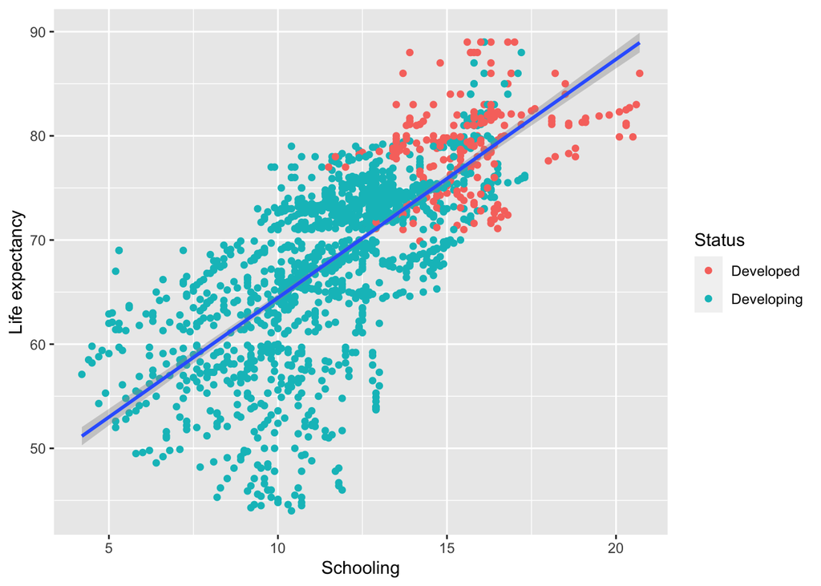

```r
lifeExpectancy %>%
  filter(Schooling > 0) %>%
  drop_na() %>%
  ggplot(aes(Schooling, `Life expectancy`)) +
  geom_point(aes(color = Status)) +
  geom_smooth(method = lm)
```

```r
subset <- lifeExpectancy %>%
  filter(Schooling > 0)
summary(lm(`Life expectancy` ~ Schooling, data = subset))
```

```
##
## Call:
## lm(formula = `Life expectancy` ~ Schooling, data = subset)
##
## Residuals:
##      Min       1Q   Median       3Q      Max
## -24.9571  -2.7750   0.7344   3.8731  15.4014
##
## Coefficients:
##             Estimate Std. Error t value Pr(>|t|)
## (Intercept) 41.29864    0.44008   93.84   <2e-16 ***
## Schooling    2.32075    0.03516   66.00   <2e-16 ***
## ---
## Signif. codes:  0 '***' 0.001 '**' 0.01 '*' 0.05 '.' 0.1 ' ' 1
##
## Residual standard error: 5.8 on 2740 degrees of freedom
##   (5 observations deleted due to missingness)
## Multiple R-squared:  0.6139, Adjusted R-squared:  0.6138
## F-statistic:  4356 on 1 and 2740 DF,  p-value: < 2.2e-16
```

Base on the output, the result is pretty obvious, a clear strong linear regression, and indicate a positive correlation between schooling and life expectancy.

The p-value is much less than 0.05, so we can reject null hypothesis.

The r-square is 0.61, indicating that approximately 61% of the variation is accounted for by this regression model.

### t-test

Then, lets do a t-test to investigate whether there is a difference in life expectancy between developed and developing countries.

The null hypothesis for this question is that the difference in average life expectancy between the two groups is zero.

```r
t.test(`Life expectancy` ~ Status, data = lifeExpectancy)
```

```
##
##  Welch Two Sample t-test
##
## data:  Life expectancy by Status
## t = 47.868, df = 1807, p-value < 2.2e-16
## alternative hypothesis: true difference in means between group Developed and group Developing is not equal to 0
## 95 percent confidence interval:
##  11.59118 12.58159
## sample estimates:
##  mean in group Developed mean in group Developing
##                 79.19785                 67.11147
```

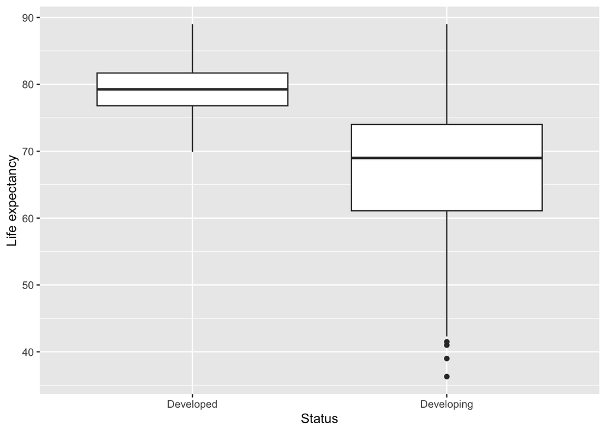

```r
lifeExpectancy %>%
  ggplot(aes(Status, `Life expectancy`)) +
  geom_boxplot()
```

Base on the t-test result, the resulting p-value was much less than 0.05. Therefore, we can reject the null hypothesis, indicating that the mean life expectancy differs significantly between developed and developing countries.

```r
schooling15 <- filter(lifeExpectancy, Schooling >= 15)
t.test(Schooling ~ Status, data = schooling15)
```

```
##
##  Welch Two Sample t-test
##
## data:  Schooling by Status
## t = 8.4376, df = 512.82, p-value = 3.323e-16
## alternative hypothesis: true difference in means between group Developed and group Developing is not equal to 0
## 95 percent confidence interval:
##  0.5867518 0.9429169
## sample estimates:
##  mean in group Developed mean in group Developing
##                 16.66433                 15.89949
```

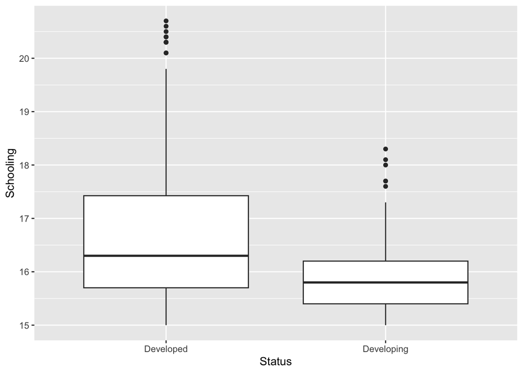

```r
schooling15 %>%
  ggplot(aes(Status, Schooling)) +
  geom_boxplot()
```

## Conclusion

This is a comprehensive and interesting data set, and a lot of other factors needs us to analyze more. We will do the further research in the future.